# Моментум-стратегии и reality check (ТЗ 29.07.2015)

> Количество исследумых компаний – **52**

#### **Таблица 1. Исследуемые компании**

|  | TICKERS | SHORT_NAME | INDUSTRY_SECTOR | INDUSTRY_GROUP | CUR_MKT_CAP | EQY_FREE_FLOAT_PCT | Mar.CAP.Adj..on.free.float |
| --- | --- | --- | --- | --- | --- | --- | --- |
| 1 | AFKS RX Equity | SISTEMA JSFC | Communications | Telecommunications | 163857000000 | 32.88 | 53876673171 |
| 2 | AFLT RX Equity | AEROFLOT | Consumer. Cyclical | Airlines | 45501949770.03 | 40.44 | 18400588069.84 |
| 3 | AKRN RX Equity | ACRON | Basic Materials | Chemicals | 91931112000 | 15.36 | 14119699492.08 |
| 4 | ALRS RX Equity | ALROSA AO | Basic Materials | Mining | 493158098584.8 | 22.88 | 112834079798.1 |
| 5 | BANE RX Equity | BASHNEFT | Energy | Oil&amp;Gas | 305809000000 | 15.67 | 47907242836.6 |
| 6 | BISV RX Equity | BASHINFORMSVYAZ | Communications | Telecommunications | 7924349064 | 100 | 7924349064 |
| 7 | BSPB RX Equity | BANK ST PETERSBU | Financial | Banks | 18197535600 | 32.13 | 5846304064.68 |
| 8 | CHMF RX Equity | SEVERSTAL PAO | Basic Materials | Iron/Steel | 515113204034 | 20.78 | 107048971654.81 |
| 9 | DIXY RX Equity | DIXY GROUP | Consumer. Non-cyclical | Food | 49213875000 | 45.01 | 22152149415 |
| 10 | ENRU RX Equity | ENEL RUSSIA OJSC | Utilities | Electric | 32542146500.4 | 17.14 | 5577723910.17 |

[output cut: 42 more lines]

> Период отслеживания менялся от **1** до **12** месяцев

> Период ожидания менялся от **0** до **8** недель

> Период инвестирования менялся от **1** до **12** месяцев

## 1. Моментум стратегии при равных весах. Ранжирование по средней доходности (бенчмарк 6% годовых - только для reality check)

> Всего было рассмотрено **5184** стратегий

#### **Таблица 2. Все стратегии**

|  | mean | t | p-value | hist_per | moment_per | invest_per | percent | pBoot |
| --- | --- | --- | --- | --- | --- | --- | --- | --- |
| 1 | 0.007955 | 1.784945 | 0.078425 | 4 | 0 | 4 | 0.5 | 0.3 |
| 2 | 0.00672 | 2.43645 | 0.017272 | 4 | 0 | 8 | 0.5 | 0.34 |
| 3 | 0.004515 | 1.710852 | 0.091355 | 4 | 0 | 12 | 0.5 | 0.364 |
| 4 | 0.003834 | 1.833895 | 0.070745 | 4 | 0 | 16 | 0.5 | 0.37 |
| 5 | 0.002833 | 1.656301 | 0.101953 | 4 | 0 | 20 | 0.5 | 0.374 |
| 6 | 0.003445 | 2.152086 | 0.034698 | 4 | 0 | 24 | 0.5 | 0.38 |
| 7 | 0.004068 | 2.816603 | 0.006238 | 4 | 0 | 28 | 0.5 | 0.39 |
| 8 | 0.004721 | 3.164068 | 0.002269 | 4 | 0 | 32 | 0.5 | 0.392 |
| 9 | 0.005659 | 3.646872 | 0.000495 | 4 | 0 | 36 | 0.5 | 0.408 |
| 10 | 0.005782 | 3.783925 | 0.000314 | 4 | 0 | 40 | 0.5 | 0.412 |

[output cut: 5174 more lines]

> Лучшая по средней доходности стратегия дает среднемесячную доходность **4.89** **%** и имеет параметры: период отбора – **11** месяцев, период ожидания – **2** недель, период инвестирования – **1** месяцев, процентиль – **0.1**

> Bootstrap p-value равен **0.038**

> Всего портфелей у лучшей стратегии – **74** Количество отрицательных доходностей у лучшей стратегии – **26** ( **35.14%** )

#### **Рисунок 1.**

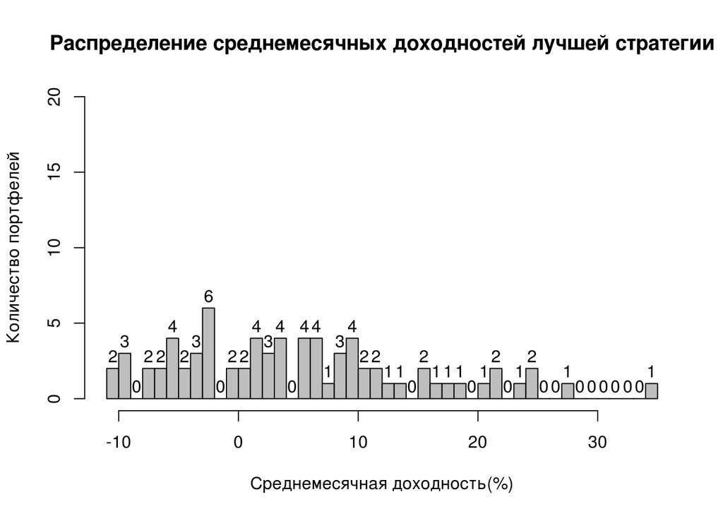

#### **Рисунок 2. (вертикальные пунктирные линии - начало нового года)**

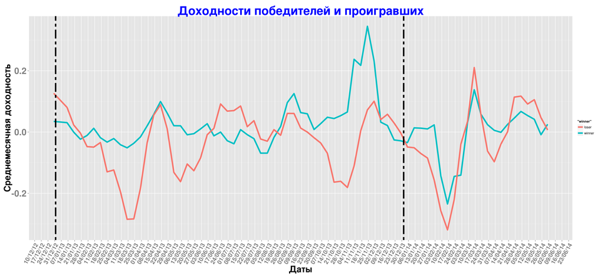

#### **Таблица 3. Доходности победителей и проигравших**

|  | date | winner | loser | delta |
| --- | --- | --- | --- | --- |
| 1 | 2012-12-30 | 0.0348 | 0.1266 | -0.0918 |
| 2 | 2013-01-13 | 0.0306 | 0.0805 | -0.0499 |
| 3 | 2013-01-20 | -0.0005 | 0.0229 | -0.0234 |
| 4 | 2013-01-27 | -0.0234 | -0.0034 | -0.02 |
| 5 | 2013-02-03 | -0.0111 | -0.0476 | 0.0365 |
| 6 | 2013-02-10 | 0.0122 | -0.0492 | 0.0614 |
| 7 | 2013-02-17 | -0.0185 | -0.0342 | 0.0157 |
| 8 | 2013-02-24 | -0.0329 | -0.1299 | 0.097 |
| 9 | 2013-03-03 | -0.0213 | -0.1239 | 0.1027 |
| 10 | 2013-03-10 | -0.0415 | -0.1947 | 0.1533 |

[output cut: 64 more lines]

## 2. Моментум стратегии при равных весах. Ранжирование по t-статистике (бенчмарк 6% годовых - только для reality check)

> Лучшая по t-статистике стратегия дает среднемесячную доходность **2.92** **%** и имеет параметры: период отбора – **11** месяцев, период ожидания – **1** недель, период инвестирования – **9** месяцев, процентиль – **0.2**

> Bootstrap p-value равен **0.044**

> Всего портфелей у лучшей по t-статистике стратегии – **74** Количество отрицательных доходностей у лучшей по t-статистике стратегии – **0** ( **0%** )

#### **Рисунок 3.**

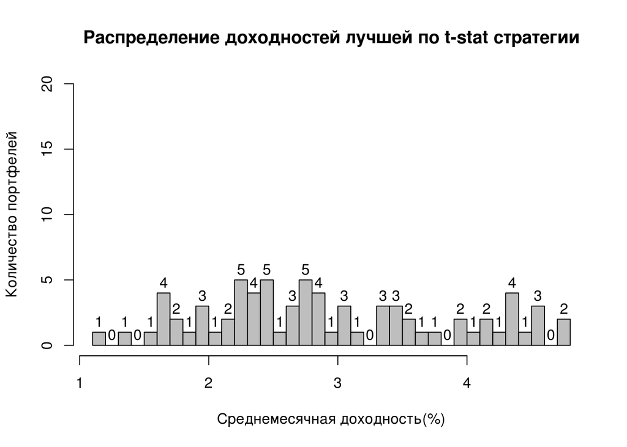

#### **Рисунок 4. (вертикальные пунктирные линии - начало нового года)**

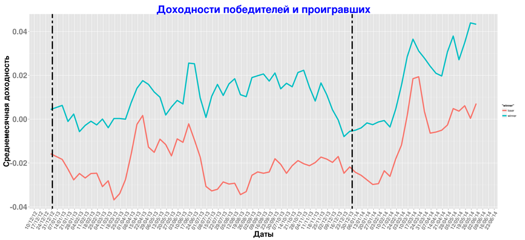

#### **Таблица 4. Доходности победителей и проигравших**

|  | date | winner | loser | delta |
| --- | --- | --- | --- | --- |
| 1 | 2012-12-30 | 0.0044 | -0.0158 | 0.0202 |
| 2 | 2013-01-13 | 0.0063 | -0.0183 | 0.0246 |
| 3 | 2013-01-20 | -0.001 | -0.0228 | 0.0217 |
| 4 | 2013-01-27 | 0.0023 | -0.0277 | 0.03 |
| 5 | 2013-02-03 | -0.0057 | -0.0248 | 0.0191 |
| 6 | 2013-02-10 | -0.0028 | -0.0268 | 0.024 |
| 7 | 2013-02-17 | -0.0009 | -0.0248 | 0.0238 |
| 8 | 2013-02-24 | -0.0026 | -0.0246 | 0.022 |
| 9 | 2013-03-03 | 0 | -0.0308 | 0.0308 |
| 10 | 2013-03-10 | -0.0039 | -0.0281 | 0.0242 |

[output cut: 64 more lines]

## 4. Моментум стратегии при равных весах. Ранжирование по средней доходности (бенчмарк 6% годовых) для компаний с максимальной рыночной капитализацией